# Informe diagnóstico de las bases de datos

María Eugenia Bernaschini

31/3/2021

# Introducción

El objetivo del presente informe es reportar el estado actual de la bases de datos y dejar registro de los nuevos ficheros generados.

Por el momento, el fichero 2020 no se incluye en el análisis.

# Sobre los ficheros importados

Se importaron a R las siguientes bases de datos .sav de SPSS:

|  | 2014 | 2015 | 2016 | 2018 |
| --- | --- | --- | --- | --- |
| Nombre del archivo | Niños_Padres_FONCyT_2014_v01_17.sav | Niños_FONCYT_2015.sav | Niños_2016.sav | Adolescentes_2018_CVRS+Antropometria.sav |
| Cantidad de variables | 306 | 121 | 161 | 137 |
| Cantidad de observaciones | 513 | 463 | 444 | 167 |

## Tipos de variables y cantidad de valores perdidos (NAs) de cada fichero por variable

|  | Tipo de variable | Cantidad de NAs | Fracción de NAs |
| --- | --- | --- | --- |
| COD | numeric | 0 | 0 |
| Escuela | factor | 15 | 0.03 |
| Grado | numeric | 15 | 0.03 |
| Turno | factor | 16 | 0.03 |
| FechaAdmin1 | numeric | 15 | 0.03 |
| Sexo | factor | 15 | 0.03 |
| Edad | numeric | 15 | 0.03 |
| edadcalculada | numeric | 15 | 0.03 |
| FechaNc | numeric | 15 | 0.03 |
| gh_y01 | factor | 16 | 0.03 |

[output cut: 296 more lines]

|  | Tipo de variable | Cantidad de NAs | Fracción de NAs |
| --- | --- | --- | --- |
| COD | numeric | 0 | 0 |
| Escuela2015 | factor | 0 | 0 |
| Grado2015 | numeric | 0 | 0 |
| Turno2015 | factor | 4 | 0.01 |
| FechaAdmin12015 | numeric | 0 | 0 |
| Sexo2015 | factor | 0 | 0 |
| Edad2015 | numeric | 0 | 0 |
| FechaNc2015 | numeric | 41 | 0.09 |
| gh_y012015 | factor | 5 | 0.01 |
| k01_y032015 | factor | 7 | 0.02 |

[output cut: 111 more lines]

|  | Tipo de variable | Cantidad de NAs | Fracción de NAs |
| --- | --- | --- | --- |
| COD | numeric | 0 | 0 |
| Escuela2016 | factor | 0 | 0 |
| Grado2016 | numeric | 0 | 0 |
| Turno2016 | factor | 0 | 0 |
| FechaAdmin12016 | numeric | 1 | 0 |
| Sexo2016 | factor | 0 | 0 |
| Edad2016 | numeric | 1 | 0 |
| FechaNc2016 | numeric | 36 | 0.08 |
| Secundaria | character | 0 | 0 |
| I6.cambios | factor | 1 | 0 |

[output cut: 151 more lines]

|  | Tipo de variable | Cantidad de NAs | Fracción de NAs |
| --- | --- | --- | --- |
| COD | numeric | 0 | 0 |
| IPEM | character | 0 | 0 |
| Curso2018 | numeric | 40 | 0.24 |
| Turno2018 | factor | 70 | 0.42 |
| FechaAdmin2018 | numeric | 0 | 0 |
| Sexo2018 | factor | 0 | 0 |
| Edad2018 | numeric | 2 | 0.01 |
| FechaNc2018 | numeric | 0 | 0 |
| I6.cambios | factor | 4 | 0.02 |
| KY10INGH | factor | 3 | 0.02 |

[output cut: 127 more lines]

A continuación se muestran las cantidades de NAs absolutas por variable de cada fichero.

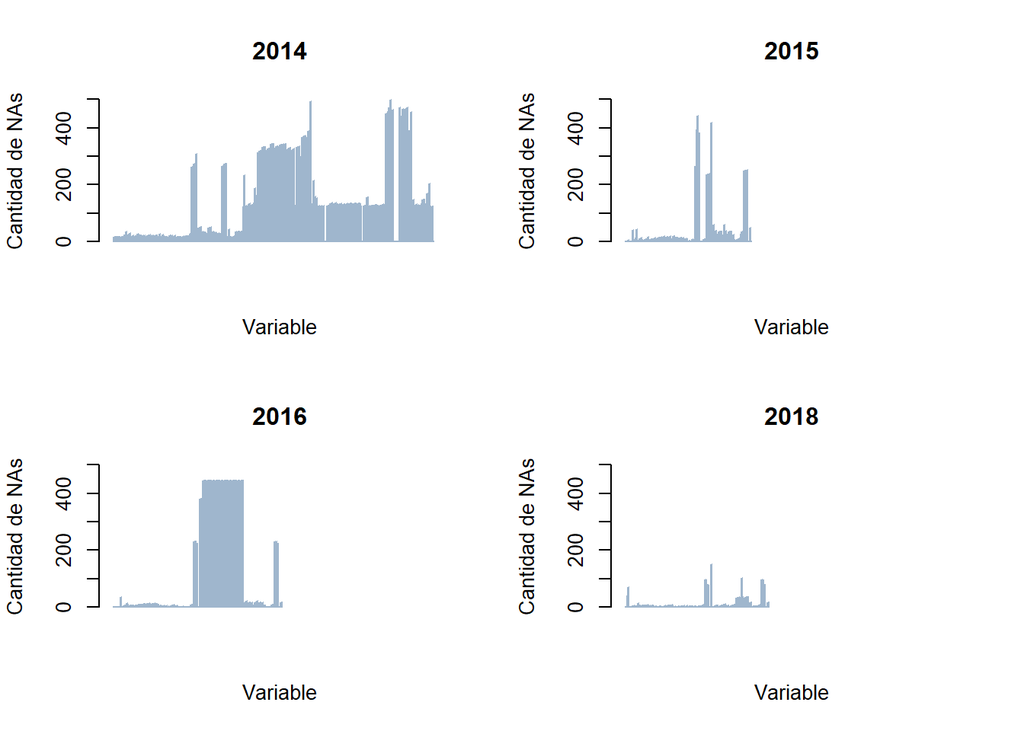

Fracciones de NAs por variable de cada fichero.

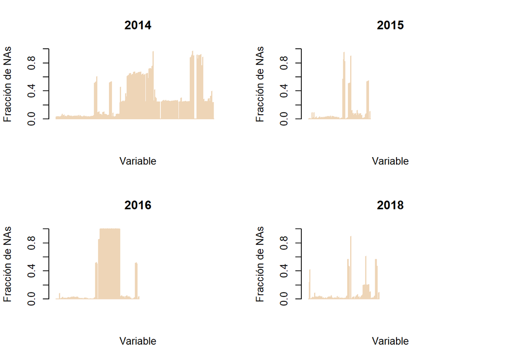

Resumen NAs por variable para cada fichero

|  | 2014 | 2015 | 2016 | 2018 |
| --- | --- | --- | --- | --- |
| Promedio de NAs absolutos | 125.98 | 43.97 | 122.73 | 13.30 |
| Mediana de NAs absolutos | 126.00 | 12.00 | 9.00 | 4.00 |
| Promedio de NAs relativos | 0.25 | 0.10 | 0.28 | 0.08 |
| Mediana de NAs relativos | 0.25 | 0.03 | 0.02 | 0.02 |
| Total de NAs | 38551.00 | 5320.00 | 19759.00 | 1822.00 |
| Fracción del total de NAs | 0.25 | 0.09 | 0.28 | 0.08 |

## Cantidad de NAs por observación

| COD | Cantidad de NAs | Fracción de NAs |
| --- | --- | --- |
| 1 | 172 | 0.56 |
| 2 | 55 | 0.18 |
| 3 | 50 | 0.16 |
| 4 | 67 | 0.22 |
| 5 | 51 | 0.17 |
| 6 | 172 | 0.56 |
| 8 | 61 | 0.2 |
| 9 | 58 | 0.19 |
| 10 | 53 | 0.17 |
| 11 | 172 | 0.56 |

[output cut: 503 more lines]

| COD | Cantidad de NAs | Fracción de NAs |
| --- | --- | --- |
| 1 | 12 | 0.1 |
| 2 | 8 | 0.07 |
| 4 | 9 | 0.07 |
| 5 | 8 | 0.07 |
| 6 | 8 | 0.07 |
| 8 | 9 | 0.07 |
| 9 | 10 | 0.08 |
| 10 | 8 | 0.07 |
| 12 | 8 | 0.07 |
| 13 | 9 | 0.07 |

[output cut: 453 more lines]

| COD | Cantidad de NAs | Fracción de NAs |
| --- | --- | --- |
| 1 | 42 | 0.26 |
| 2 | 43 | 0.27 |
| 3 | 43 | 0.27 |
| 4 | 44 | 0.27 |
| 5 | 43 | 0.27 |
| 6 | 43 | 0.27 |
| 8 | 68 | 0.42 |
| 9 | 43 | 0.27 |
| 10 | 43 | 0.27 |
| 12 | 43 | 0.27 |

[output cut: 434 more lines]

| COD | Cantidad de NAs | Fracción de NAs |
| --- | --- | --- |
| 40 | 6 | 0.04 |
| 860 | 12 | 0.09 |
| 868 | 6 | 0.04 |
| 237 | 6 | 0.04 |
| 59 | 6 | 0.04 |
| 294 | 8 | 0.06 |
| 309 | 19 | 0.14 |
| 817 | 7 | 0.05 |
| 893 | 5 | 0.04 |
| 64 | 18 | 0.13 |

[output cut: 157 more lines]

A continuación se muestran las cantidades de NAs absolutas por observación de cada fichero.

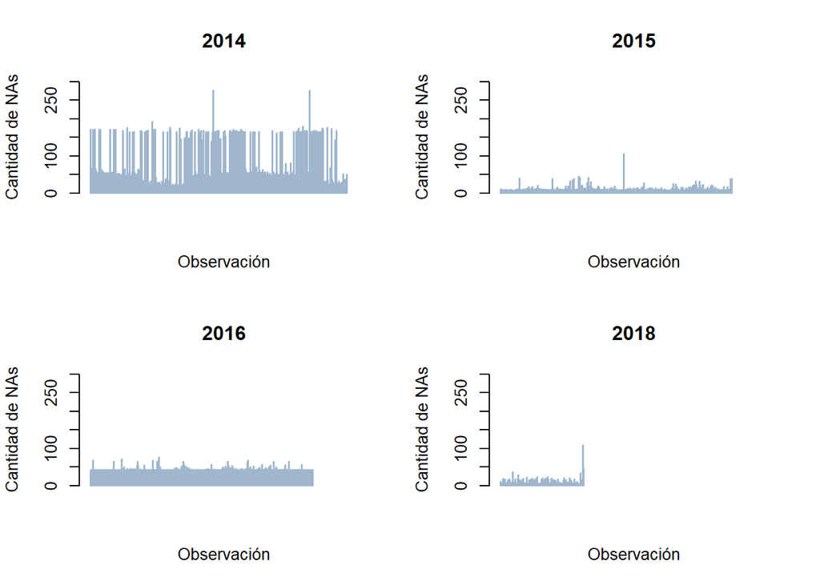

Fracciones de NAs por observación de cada fichero.

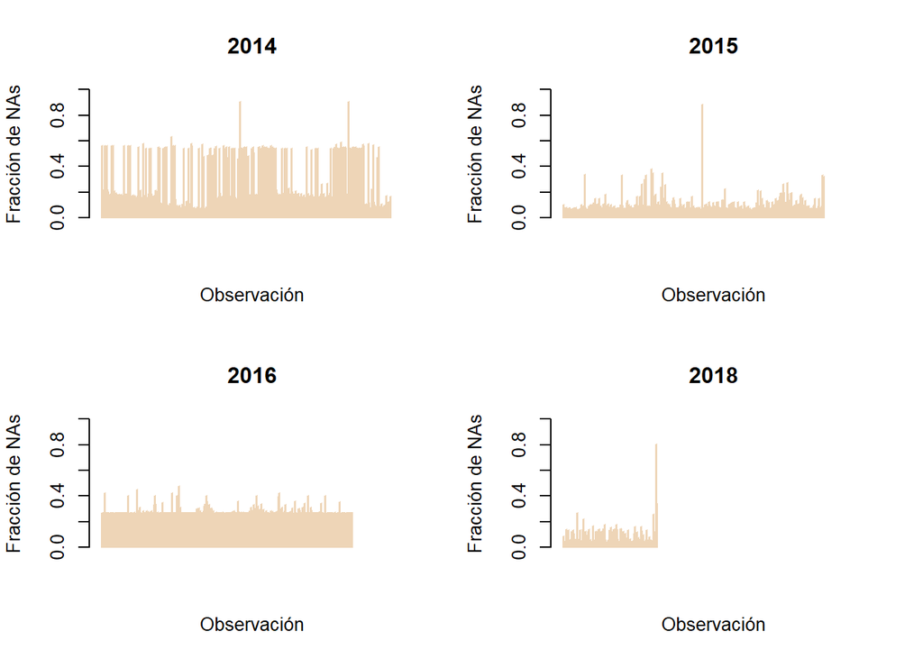

Resumen NAs por observación para cada fichero

|  | 2014 | 2015 | 2016 | 2018 |
| --- | --- | --- | --- | --- |
| Promedio de NAs absolutos | 75.15 | 11.49 | 44.50 | 10.91 |
| Mediana de NAs absolutos | 51.00 | 9.00 | 43.00 | 7.00 |
| Promedio de NAs relativos | 0.25 | 0.09 | 0.28 | 0.08 |
| Mediana de NAs relativos | 0.17 | 0.07 | 0.27 | 0.05 |
| Total de NAs | 38551.00 | 5320.00 | 19759.00 | 1822.00 |
| Fracción del total de NAs | 0.25 | 0.09 | 0.28 | 0.08 |

## Comparación de las variables entre ficheros

En la siguiente tabla se pueden observar las variables que contiene cada fichero y fácilmente comparar un fichero con otro.

|  | 2014 | 2015 | 2016 | 2018 |
| --- | --- | --- | --- | --- |
| 1 | COD | COD | COD | COD |
| 2 | Escuela | Escuela2015 | Escuela2016 | IPEM |
| 3 | Grado | Grado2015 | Grado2016 | Curso2018 |
| 4 | Turno | Turno2015 | Turno2016 | Turno2018 |
| 5 | FechaAdmin1 | FechaAdmin12015 | FechaAdmin12016 | FechaAdmin2018 |
| 6 | Sexo | Sexo2015 | Sexo2016 | Sexo2018 |
| 7 | Edad | Edad2015 | Edad2016 | Edad2018 |
| 8 | edadcalculada |  |  |  |
| 9 | FechaNc | FechaNc2015 | FechaNc2016 | FechaNc2018 |
| 10 |  |  | Secundaria |  |

[output cut: 369 more lines]

# Conclusiones

Para estudio longitudinales se recomienda usar el mismo nombre para las variables en todos los períodos, indicando el año con un sufijo (salvo la variable que identifica al sujeto). Por ejemplo: “Grado_2014”, “Grado_2015”, “Grado_2016”, “Grado_2018” o “Grado2014”, “Grado2015”, “Grado2016”, “Grado2018”.

**En cuanto a los NAs por variable**

- El fichero 2014 contiene variables con más de un 50% de NAs (las que comienzan con la letra C, en general).
- El fichero 2016 contiene variables sin datos (las que comienzan con XIV).

**En cuanto a los NAs por observación**

- El fichero 2014 contiene muchas observaciones con más de un 50% de NAs. Habría que repetir el análisis teniendo en cuenta sólo las variables más importantes.
- Para el fichero 2016 el promedio de NAs por observación es de un 28%, pero se debe al hecho de que hay muchas variables vacías.

# Nuevos ficheros

El objetivo del proyecto es realizar un análisis longitudinal de los datos, para ello es necesario generar un fichero que reúna todas las medidas repetidas obtenidas a lo largo del tiempo.

Para comenzar con el análisis exploratorio de los datos se crearon dos ficheros madres. Uno contiene el total de observaciones y el otro el total de observaciones completas (esto es, sólo las personas con datos en todos los períodos). El primer fichero se llama **base_madre_grande.csv** y el segundo **base_madre_chica.csv**. Los nombres de las variables en ambos ficheros madres se preservaron añadiendo un sufijo que indica el año de observación.

```r
write.csv(base.madre.chica,"base_madre_chica.csv", row.names = FALSE)

write.csv(base.madre.grande,"base_madre_grande.csv", row.names = FALSE)

# para leerlas:
# base.madre.grande <- read.csv("base_madre_grande.csv", header = TRUE, sep = ",")
# base.madre.chica <- read.csv("base_madre_chica.csv", header = TRUE, sep = ",")
```

**Observaciones:**

- La cantidad de individuos con datos en los años 2014 y 2015 es 456. Notar que la cantidad de individuos en 2015 es 463, por lo que en ese año se sumaron 7 personas que no estaban en el año 2014.
- La cantidad de individuos con datos en los años 2014, 2015 y 2016 es 424. Notar que la cantidad de individuos en 2016 es 444, por lo que en ese año se sumaron 20 personas que no estaban en el año 2014 o 2015.
- La cantidad de individuos con datos en los años 2014, 2015, 2016 y 2018 es 163. Notar que la cantidad de individuos en 2018 es 167, por lo que en ese año se sumaron 4 personas que no estaban en el año 2014, 2015 o 2016.
- La base madre grande contiene 722 variables y 522 observaciones.
- La base madre chica tiene 722 variables y 163 observaciones.

# Pasos a seguir

- Incluir el fichero 2020.
- Decidir tratamiento para NAs.
- Iniciar el análisis exploratorio de los datos.